# Data Science Pipeline Tutorial: What Are the World's Rising National Film Industries?

One of the classes I took this semester was FILM298D: Film Art in a Global Society. The course was, as you might guess, about cinema around the globe, giving a broad view of modern film industries across many countries. I got to see a lot of good movies, but I was saddened to see that most of them were not well known outside of film festivals and critical circles, as most countries' everyday movie theaters and streaming options are dominated by American and other Anglophone films. However, I also heard that the national film industries of many non-Anglophone countries are growing, and this inspired me to look at the data of global film production to determine just which countries' film industries are rising and how. In this tutorial I will seek to determine which countries' film industries are expanding the fastest, in terms of total pictures produced annually, pictures produced intranationally, and pictures produced via international coproductions.

*Tim Hicks*

## Outline

1. Data Scraping
1. Managing the Data
2. Tidying the Data
2. Preliminary Data Representation
1. Data Analysis
3. Hypothesis Testing and Machine Learning
1. New Data Representation
2. Further Data Analysis
4. Conclusion

Here are all of the libraries we will use in our analysis:

```python
!pip install folium
import folium
import pandas as pd
import requests
import numpy as np
import matplotlib.pyplot as plt
import matplotlib.cm as cm
import matplotlib.colors as colors
from sklearn import linear_model
```

## Data Scraping

We will be getting national film data from the UNESCO Institute for Statistics, available at http://data.uis.unesco.org/. The table I want to use is "Culture/Feature Films/Feature Films (full dataset)". I have downloaded the table and have reuploaded it to GitHub for use here. This data set covers the film production of most countries in the world from 2011 to 2017.

```python
df = pd.read_csv('https://raw.githubusercontent.com/cactusTim/cactusTim.github.io/master/CUL_DS_15052021224656678.csv')
df
```

|  | INDICATOR | Indicator | LOCATION | Country | TIME | Time | Value | Flag Codes | Flags |
| --- | --- | --- | --- | --- | --- | --- | --- | --- | --- |
| 0 | 220000 | Criteria used to classify a national feature f... | AUS | Australia | 2011 | 2011 | 3.0 | NaN | NaN |
| 1 | 220000 | Criteria used to classify a national feature f... | AUS | Australia | 2012 | 2012 | 3.0 | NaN | NaN |
| 2 | 220000 | Criteria used to classify a national feature f... | AUS | Australia | 2013 | 2013 | 3.0 | NaN | NaN |
| 3 | 220000 | Criteria used to classify a national feature f... | AUS | Australia | 2014 | 2014 | 3.0 | NaN | NaN |
| 4 | 220000 | Criteria used to classify a national feature f... | AUS | Australia | 2015 | 2015 | 3.0 | NaN | NaN |
| ... | ... | ... | ... | ... | ... | ... | ... | ... | ... |
| 31387 | 220052 | Number of indoor cinemas that are multiplexes ... | DZA | Algeria | 2017 | 2017 | NaN | n | Magnitude nil or negligible |
| 31388 | FPCIND_S8T99 | Percentage of indoor cinema that are multiplex... | DZA | Algeria | 2016 | 2016 | NaN | ‡; n | UIS Estimation; Magnitude nil or negligible |
| 31389 | FPCIND_S8T99 | Percentage of indoor cinema that are multiplex... | DZA | Algeria | 2017 | 2017 | NaN | n | Magnitude nil or negligible |
| 31390 | 220214 | Number of screens equipped for digital feature... | DZA | Algeria | 2016 | 2016 | NaN | n | Magnitude nil or negligible |
| 31391 | 220214 | Number of screens equipped for digital feature... | DZA | Algeria | 2017 | 2017 | NaN | n | Magnitude nil or negligible |

31392 rows × 9 columns

The table above has several columns that are redundant and/or useless for our purposes, so I am dropping them here so we won't have to look at them anymore.

```python
df = df.drop(columns=['INDICATOR','LOCATION','TIME','Flag Codes','Flags'])
```

### Managing the Data

At over 30,000 rows of information, we suddenly have a lot of data! This single UNESCO table contains 76 different categories—indicated by the "Indicator" column—of information on feature film production, distribution of feature films, cinema infrastructure, and exhibition of feature films, and while all of it is interesting, most of it is extraneous for our purposes here. So, to make this data set more managable, I will extract three smaller tables containing the information we want. We can discard the rest.

What is the information we want? In this analysis we are looking at three main figures:

- Total number of feature films produced by each country each year
- Number of feature films that are produced 100% intranationally by each country each year
- Number of feature films that are produced as international coproductions by each country each year

To be "produced by" a given country, at least one of a film's producers must be of that country. The film does not have to be shot, edited, or anything else in that country, merely funded there. This means that films that are international coproductions have multiple producers of multiple national origins.

First, the total number of feature films produced by each country each year. This value will be equal to the sum of the intranational productions and the coproductions of each country each year, so we shouldn't have to extract this table at all if we didn't want to, since we can just derive the value ourselves from our other data. But there are some countries and years for which this is the only data we have, with no additional breakdowns into domestic vs. international productions, so we need to take this table by itself as well if we want to have maximum access to the data.

```python
# Make a copy of the dataframe, but only the rows for which the "Indicator" column reads 'Total number of national feature films produced'
natfilms = df[df['Indicator'] == 'Total number of national feature films produced']
natfilms
```

|  | Indicator | Country | Time | Value |
| --- | --- | --- | --- | --- |
| 459 | Total number of national feature films produced | Australia | 2011 | 43.0 |
| 460 | Total number of national feature films produced | Australia | 2012 | 29.0 |
| 461 | Total number of national feature films produced | Australia | 2013 | 26.0 |
| 462 | Total number of national feature films produced | Australia | 2014 | 39.0 |
| 463 | Total number of national feature films produced | Australia | 2015 | 33.0 |
| ... | ... | ... | ... | ... |
| 30581 | Total number of national feature films produced | Suriname | 2017 | NaN |
| 31258 | Total number of national feature films produced | Qatar | 2016 | 54.0 |
| 31259 | Total number of national feature films produced | Qatar | 2017 | 54.0 |
| 31260 | Total number of national feature films produced | Saint Vincent and the Grenadines | 2016 | NaN |
| 31261 | Total number of national feature films produced | Saint Vincent and the Grenadines | 2017 | NaN |

650 rows × 4 columns

There. Reducing a table from 31392 rows to 650 rows feels good, doesn't it? Like you're Pygmalion, chiseling off a huge chunk of ivory as you are begin to carve a brand new statue. I'm guessing. I've never chiseled anything in my life. Anyway, now that this table is able to stand alone, we should also drop the "Indicator" column, since it is no longer providing useful information.

```python
natfilms = natfilms.drop(columns=['Indicator'])
natfilms
```

|  | Country | Time | Value |
| --- | --- | --- | --- |
| 459 | Australia | 2011 | 43.0 |
| 460 | Australia | 2012 | 29.0 |
| 461 | Australia | 2013 | 26.0 |
| 462 | Australia | 2014 | 39.0 |
| 463 | Australia | 2015 | 33.0 |
| ... | ... | ... | ... |
| 30581 | Suriname | 2017 | NaN |
| 31258 | Qatar | 2016 | 54.0 |
| 31259 | Qatar | 2017 | 54.0 |
| 31260 | Saint Vincent and the Grenadines | 2016 | NaN |
| 31261 | Saint Vincent and the Grenadines | 2017 | NaN |

650 rows × 3 columns

Nice.

Next, we do the same thing for the number of feature films that are produced 100% intranationally by each country each year:

```python
intrafilms = df[df['Indicator'] == 'Number of feature films 100% nationally produced']
intrafilms = intrafilms.drop(columns=['Indicator'])
intrafilms
```

|  | Country | Time | Value |
| --- | --- | --- | --- |
| 3724 | Australia | 2011 | 39.0 |
| 3725 | Australia | 2012 | 26.0 |
| 3726 | Australia | 2013 | 24.0 |
| 3727 | Australia | 2014 | 38.0 |
| 3728 | Australia | 2015 | 32.0 |
| ... | ... | ... | ... |
| 30708 | Suriname | 2017 | NaN |
| 31298 | Qatar | 2016 | NaN |
| 31299 | Qatar | 2017 | NaN |
| 31300 | Saint Vincent and the Grenadines | 2016 | NaN |
| 31301 | Saint Vincent and the Grenadines | 2017 | NaN |

505 rows × 3 columns

Finally, the number of feature films that are produced as international coproductions by each country each year:

```python
cofilms = df[df['Indicator'] == 'Number of internationally coproduced feature films']
cofilms = cofilms.drop(columns=['Indicator'])
cofilms
```

|  | Country | Time | Value |
| --- | --- | --- | --- |
| 5674 | Australia | 2011 | 4.0 |
| 5675 | Australia | 2012 | 3.0 |
| 5676 | Australia | 2013 | 2.0 |
| 5677 | Australia | 2014 | 1.0 |
| 5678 | Australia | 2015 | 1.0 |
| ... | ... | ... | ... |
| 30748 | Suriname | 2017 | NaN |
| 31318 | Qatar | 2016 | 54.0 |
| 31319 | Qatar | 2017 | 54.0 |
| 31320 | Saint Vincent and the Grenadines | 2016 | NaN |
| 31321 | Saint Vincent and the Grenadines | 2017 | NaN |

497 rows × 3 columns

### Tidying the Data

Now that we have just the data we want, we can begin working with it, right? If you want to, sure. But the data is still a bit obtuse, so I want to refine it a bit further. At the moment, each of our three tables has multiple rows for each year and multiple rows for each country, which makes it a bit difficult to process or even look at the data without some unnecessary stress. So to resolve that, I am pivoting each of the tables so that there is one row for each year and one column for each country. Then I am dropping the "Value" super-header, since it adds no new information. This way it will be easy to look up the number of films of any type produced by any country in any year without having to use any more code than we have to.

```python
natfilms = natfilms.pivot(index='Time', columns='Country')
natfilms.columns = natfilms.columns.droplevel()
```

```python
intrafilms = intrafilms.pivot(index='Time', columns='Country')
intrafilms.columns = intrafilms.columns.droplevel()
```

```python
cofilms = cofilms.pivot(index='Time', columns='Country')
cofilms.columns = cofilms.columns.droplevel()
```

Here's our "total films per year" table with the pivot applied. The other two tables look similar enough that they don't need to be shown too:

```python
natfilms
```

| Country Time | Albania | Algeria | Andorra | Angola | Argentina | Armenia | Aruba | Australia | Austria | Azerbaijan | ... | Tunisia | Turkey | Ukraine | United Arab Emirates | United Kingdom of Great Britain and Northern Ireland | United States of America | Uruguay | Uzbekistan | Venezuela (Bolivarian Republic of) | Viet Nam |
| --- | --- | --- | --- | --- | --- | --- | --- | --- | --- | --- | --- | --- | --- | --- | --- | --- | --- | --- | --- | --- | --- |
| 2011 | NaN | NaN | NaN | NaN | 100.0 | 5.0 | NaN | 43.0 | 54.0 | 63.0 | ... | 11.0 | 70.0 | 3.0 | NaN | 299.0 | 819.0 | 8.0 | NaN | 16.0 | 75.0 |
| 2012 | NaN | NaN | NaN | NaN | 141.0 | 24.0 | NaN | 29.0 | 54.0 | 69.0 | ... | 8.0 | 61.0 | 7.0 | NaN | 326.0 | 738.0 | 15.0 | 66.0 | 13.0 | NaN |
| 2013 | NaN | NaN | NaN | NaN | 168.0 | 28.0 | NaN | 26.0 | 46.0 | 69.0 | ... | 8.0 | 85.0 | 12.0 | NaN | 241.0 | 738.0 | 11.0 | 53.0 | 21.0 | NaN |
| 2014 | 3.0 | NaN | NaN | NaN | 172.0 | 36.0 | NaN | 39.0 | 45.0 | 64.0 | ... | NaN | 109.0 | 7.0 | 6.0 | 339.0 | 649.0 | 11.0 | 57.0 | 17.0 | NaN |
| 2015 | 7.0 | NaN | NaN | NaN | 182.0 | 37.0 | NaN | 33.0 | 40.0 | 53.0 | ... | 11.0 | 137.0 | 3.0 | 11.0 | 298.0 | 663.0 | 11.0 | 47.0 | 29.0 | NaN |
| 2016 | NaN | 21.0 | NaN | 6.0 | 199.0 | 37.0 | NaN | 42.0 | 46.0 | 59.0 | ... | NaN | 135.0 | 20.0 | 69.0 | 317.0 | 656.0 | NaN | 81.0 | 26.0 | NaN |
| 2017 | NaN | 12.0 | NaN | 4.0 | 220.0 | 28.0 | NaN | 55.0 | 44.0 | 53.0 | ... | NaN | 148.0 | 19.0 | 85.0 | 285.0 | 660.0 | NaN | 92.0 | 16.0 | NaN |

7 rows × 129 columns

Much easier to read. There's one more thing I want to address before we move on, and that's countries for which there is no data saying they produced any films of a given type at all between 2011 and 2017. Andorra is a clear example above. I guess I shouldn't expect much more from a backwater mountain principality run by a Christian bishop and the President of France when he has some spare time. Since Andorra's film industry seems to have been completely dead for the whole period we are looking at, it is no use including it in our data, so I want to purge it and all others like it from our tables.

```python
# Dropping all columns from each table in which the number of films produced is NaN
# for all seven years
natfilms = natfilms.drop(natfilms.columns[natfilms.apply(lambda col: col.isnull().sum() == 7)], axis=1)
intrafilms = intrafilms.drop(intrafilms.columns[intrafilms.apply(lambda col: col.isnull().sum() == 7)], axis=1)
cofilms = cofilms.drop(cofilms.columns[cofilms.apply(lambda col: col.isnull().sum() == 7)], axis=1)
```

And here's what the total films table looks like with the changes:

```python
natfilms
```

| Country Time | Albania | Algeria | Angola | Argentina | Armenia | Australia | Austria | Azerbaijan | Bangladesh | Belarus | ... | Tunisia | Turkey | Ukraine | United Arab Emirates | United Kingdom of Great Britain and Northern Ireland | United States of America | Uruguay | Uzbekistan | Venezuela (Bolivarian Republic of) | Viet Nam |
| --- | --- | --- | --- | --- | --- | --- | --- | --- | --- | --- | --- | --- | --- | --- | --- | --- | --- | --- | --- | --- | --- |
| 2011 | NaN | NaN | NaN | 100.0 | 5.0 | 43.0 | 54.0 | 63.0 | NaN | 1.0 | ... | 11.0 | 70.0 | 3.0 | NaN | 299.0 | 819.0 | 8.0 | NaN | 16.0 | 75.0 |
| 2012 | NaN | NaN | NaN | 141.0 | 24.0 | 29.0 | 54.0 | 69.0 | NaN | NaN | ... | 8.0 | 61.0 | 7.0 | NaN | 326.0 | 738.0 | 15.0 | 66.0 | 13.0 | NaN |
| 2013 | NaN | NaN | NaN | 168.0 | 28.0 | 26.0 | 46.0 | 69.0 | NaN | NaN | ... | 8.0 | 85.0 | 12.0 | NaN | 241.0 | 738.0 | 11.0 | 53.0 | 21.0 | NaN |
| 2014 | 3.0 | NaN | NaN | 172.0 | 36.0 | 39.0 | 45.0 | 64.0 | NaN | NaN | ... | NaN | 109.0 | 7.0 | 6.0 | 339.0 | 649.0 | 11.0 | 57.0 | 17.0 | NaN |
| 2015 | 7.0 | NaN | NaN | 182.0 | 37.0 | 33.0 | 40.0 | 53.0 | NaN | NaN | ... | 11.0 | 137.0 | 3.0 | 11.0 | 298.0 | 663.0 | 11.0 | 47.0 | 29.0 | NaN |
| 2016 | NaN | 21.0 | 6.0 | 199.0 | 37.0 | 42.0 | 46.0 | 59.0 | 23.0 | NaN | ... | NaN | 135.0 | 20.0 | 69.0 | 317.0 | 656.0 | NaN | 81.0 | 26.0 | NaN |
| 2017 | NaN | 12.0 | 4.0 | 220.0 | 28.0 | 55.0 | 44.0 | 53.0 | 31.0 | NaN | ... | NaN | 148.0 | 19.0 | 85.0 | 285.0 | 660.0 | NaN | 92.0 | 16.0 | NaN |

7 rows × 117 columns

Aw yeah. So long, Andorra and your eleven fellows.

## Preliminary Data Representation

Okay, now that we are done kneading the data, we can get to the interesting parts. The first of those is creating a basic visual representation of the data so we can get a better sense of what we are working with.

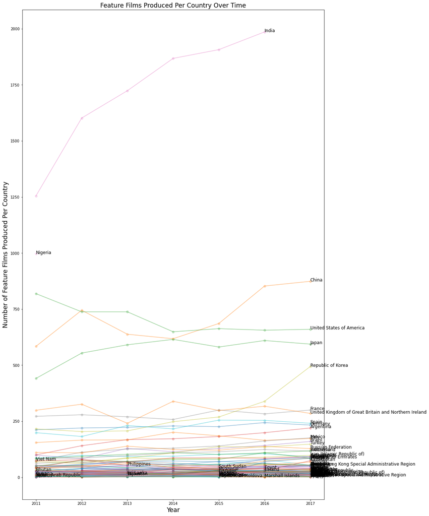

```python
# For each column header in the table (read: each country in the data), take its known film
# production numbers and plot them as colored lines on a graph, each layered above the last,
# with dots marking the data points to which each line conforms.
plt.figure(figsize=(15, 25))
for c in list(natfilms.columns.values):
    x = natfilms[c]
    plt.plot(natfilms.index.values, x, alpha=0.5)
    plt.scatter(natfilms.index.values, x, alpha=0.25)
# Label each of the lines by finding the rightmost point to which each line extends, then
# print the name of the country in question in that spot
for c in list(natfilms.columns.values):
    maxy = 2000
    for y in natfilms.index.values:
        if not(pd.isnull(natfilms.at[y,c])):
            maxy = y
    if maxy != 2000:
        plt.text(maxy,natfilms.at[maxy,c],c,size='large')
# Label the axes, title the graph, and show it
plt.xlabel('Year',size='xx-large')
plt.ylabel("Number of Feature Films Produced Per Country",size='xx-large')
plt.title('Feature Films Produced Per Country Over Time',size='xx-large')
plt.show()
```

Well, that's a bit much to look at. I'll break it down in a moment, but first, let's also plot our two more specific tables on intra- vs. inter- national films per country:

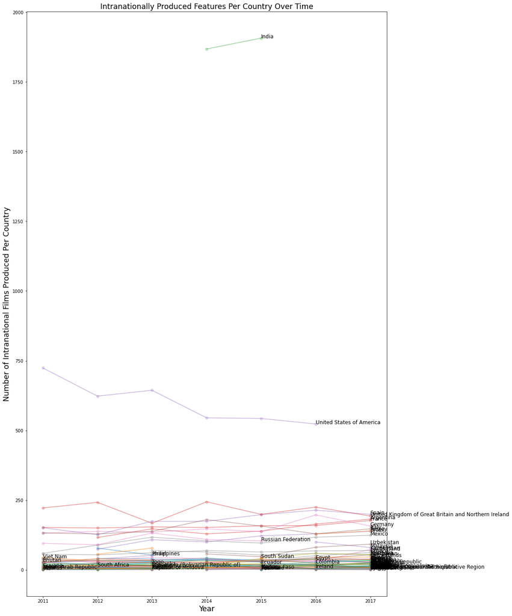

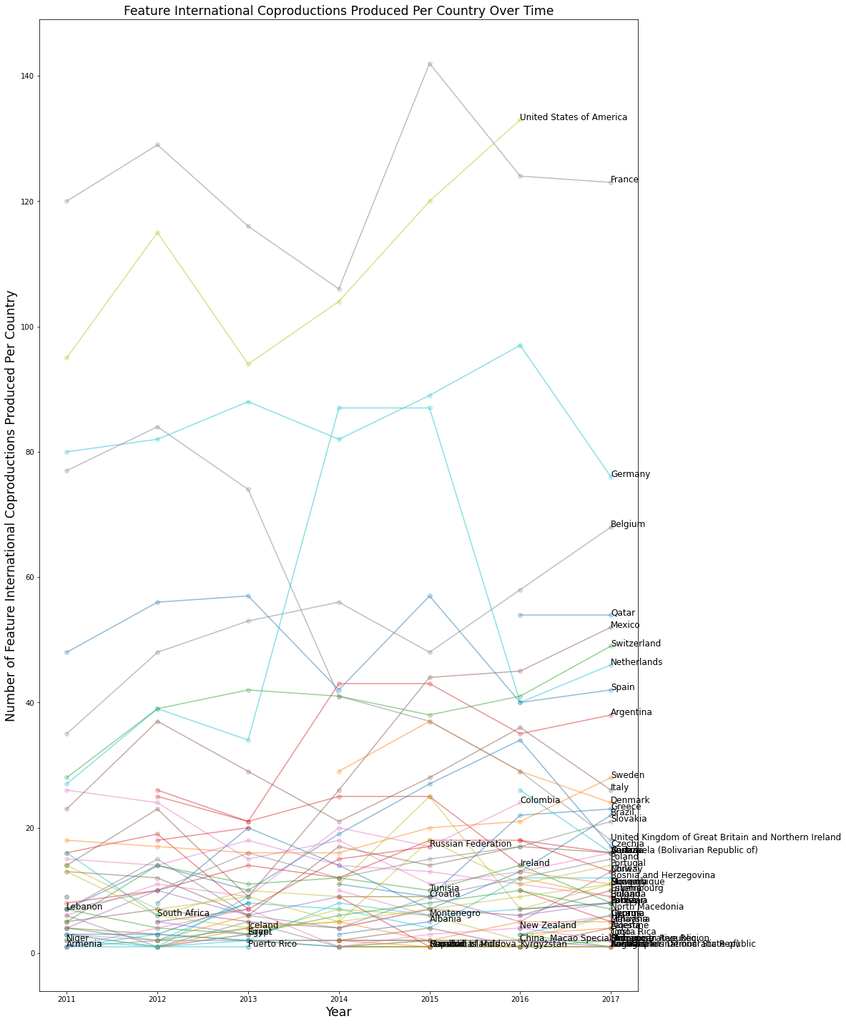

```python
# Do the same for the intranational film data
plt.figure(figsize=(15, 25))
for c in list(intrafilms.columns.values):
    x = intrafilms[c]
    plt.plot(intrafilms.index.values, x, alpha=0.5)
    plt.scatter(intrafilms.index.values, x, alpha=0.25)
for c in list(intrafilms.columns.values):
    maxy = 2000
    for y in intrafilms.index.values:
        if not(pd.isnull(intrafilms.at[y,c])):
            maxy = y
    if maxy != 2000:
        plt.text(maxy,intrafilms.at[maxy,c],c,size='large')
plt.xlabel('Year',size='xx-large')
plt.ylabel('Number of Intranational Films Produced Per Country',size='xx-large')
plt.title('Intranationally Produced Features Per Country Over Time',size='xx-large')
plt.show()

# And likewise for the international coproductions
plt.figure(figsize=(15, 25))
for c in list(cofilms.columns.values):
    x = cofilms[c]
    plt.plot(cofilms.index.values, x, alpha=0.5)
    plt.scatter(cofilms.index.values, x, alpha=0.25)
for c in list(cofilms.columns.values):
    maxy = 2000
    for y in cofilms.index.values:
        if not(pd.isnull(cofilms.at[y,c])):
            maxy = y
    if maxy != 2000:
        plt.text(maxy,cofilms.at[maxy,c],c,size='large')
plt.xlabel('Year',size='xx-large')
plt.ylabel('Number of Feature International Coproductions Produced Per Country',size='xx-large')
plt.title('Feature International Coproductions Produced Per Country Over Time',size='xx-large')
plt.show()
```

### Data Analysis

Labelling the country names corresponding to the lines on the graphs is a bit of a double edged-sword, as it is much better than having no labels at all, but most of the labels we do get overlap horribly to the point of unreadability. But these are just preliminary visualizations and will not be our most important graphs, so for our purposes it's okay if we can only read the labels for the top countries in each category. The alternative would be to make the text on each of these graphs unreasonably small, and I won't subject you to that.

Referring back to the data in the first tables, the one about total films produced each year, let's take a closer look. India is soaring far above everyone else, rising from about 1250 to 2000. Below India is a series of runners-up for the title of most feature films per year: China, the United States, and Japan, plus one really good year each for Nigeria and South Korea. Below these is a gap before everyone else is clustered at the bottom, spread from 0 to about 350.  
India's numbers are rapidly rising, China's and Japan's are slowly rising, and the US's are slowly falling. It is nearly impossible to make a gut estimate about the growth rates of the rest of the countries at this point. To do that, we need to calculate a line of best fit for each nation's film production numbers and determine which has the highest slope. We will do that in the next step, but first, let's also examine the other two graphs.

Once we calculate which countries' film industries are growing the fastest, we can use this data to determine whether this rising success is due primarily to a focus on intranational productions, international coproductions, or a relatively even mix of both. So far it seems like India's insane film industry is probably growing the fastest in addition to being the biggest, but it is unclear what countries will be the runners-up. To determine that—as well as whether India truly is the current king of cinematic growth—we will need to use hypothesis testing and machine learning.

## Hypothesis Testing and Machine Learning

We want to know how fast each country's film production system has grown or shrunk over the course of our seven-year period, so for each country we use scikit-learn's linear model to use hypothesis testing and machine learning to estimate a line of best fit for each country's film production numbers over time. But before we do this, we first create a new dataframe that will serve as a nicer hash table to store the 7-year growth coefficient corresponding to each country.

```python
filmgrowth = pd.DataFrame(np.array([[np.NaN] * len(natfilms.columns.values)]),
                          columns=natfilms.columns.values)
filmgrowth = filmgrowth.rename(index={0: 'Growth Coefficient'})
filmgrowth
```

|  | Albania | Algeria | Angola | Argentina | Armenia | Australia | Austria | Azerbaijan | Bangladesh | Belarus | ... | Tunisia | Turkey | Ukraine | United Arab Emirates | United Kingdom of Great Britain and Northern Ireland | United States of America | Uruguay | Uzbekistan | Venezuela (Bolivarian Republic of) | Viet Nam |
| --- | --- | --- | --- | --- | --- | --- | --- | --- | --- | --- | --- | --- | --- | --- | --- | --- | --- | --- | --- | --- | --- |
| Growth Coefficient | NaN | NaN | NaN | NaN | NaN | NaN | NaN | NaN | NaN | NaN | ... | NaN | NaN | NaN | NaN | NaN | NaN | NaN | NaN | NaN | NaN |

1 rows × 117 columns

Here's where scikit-learn comes in. For each country, we create an independent variable list and a dependent variable list, and fill them in with the total annual film production data for each year where it is available. Then we have scikit-learn create a linear regression to estimate its line of best fit for the country's cinematic growth, and we store the growth coefficient for that country in our new dataframe.

```python
# for each country
for c in natfilms.columns.values:
    # create empty lists for the data for the independent variable (years) and the dependent
    # variable (annual production numbers)
    ind = []
    dep = []
    # for each year in question, add it and its film count for the given country to the lists
    # if the data exists
    for y in natfilms.index.values:
        val = natfilms.at[y,c]
        if not(pd.isnull(val)):
            ind.append([y])
            dep.append(val)
    # create a linear regression to estimate a line of best fit, then store the coefficient of
    # that regression line; this is the national 7-year growth rate
    lm = linear_model.LinearRegression()
    lm.fit(ind, dep)
    filmgrowth.at['Growth Coefficient', c] = lm.coef_[0]
```

Here's what we get:

```python
filmgrowth
```

|  | Albania | Algeria | Angola | Argentina | Armenia | Australia | Austria | Azerbaijan | Bangladesh | Belarus | ... | Tunisia | Turkey | Ukraine | United Arab Emirates | United Kingdom of Great Britain and Northern Ireland | United States of America | Uruguay | Uzbekistan | Venezuela (Bolivarian Republic of) | Viet Nam |
| --- | --- | --- | --- | --- | --- | --- | --- | --- | --- | --- | --- | --- | --- | --- | --- | --- | --- | --- | --- | --- | --- |
| Growth Coefficient | 4.0 | -9.0 | -2.0 | 17.5 | 3.714286 | 2.464286 | -1.857143 | -2.357143 | 8.0 | 0.0 | ... | 0.171429 | 15.5 | 2.321429 | 29.5 | -0.107143 | -25.571429 | 0.2 | 5.828571 | 1.214286 | 0.0 |

1 rows × 117 columns

Nice. We also want to know which are the absolute fastest-expanding national film industries out of all of these, so we also make a copy of this dataframe that contains only the growth rates of the top ten countries. To do that I am dropping all columns for the copy for which the growth coefficient is below a certain threshhold. If you wanted you could write a function to figure out what that threshhold should be, but I just guessed values until I found the one I wanted: 10.5. This gives us our top ten rising national film industries: those of India, South Korea, China, the United Arab Emirates, Myanmar/Burma, Japan, Argentina, Turkey, Mexico, and Brazil. And yes, this means India absolutely is the king of national cinematic growth, wildly outpacing everybody else.

```python
topten = filmgrowth.copy(deep=True)

for c in topten.columns.values:
    if topten.at['Growth Coefficient', c] <= 10.5:
        topten = topten.drop(columns=[c])

topten
```

|  | Argentina | Brazil | China | India | Japan | Mexico | Myanmar | Republic of Korea | Turkey | United Arab Emirates |
| --- | --- | --- | --- | --- | --- | --- | --- | --- | --- | --- |
| Growth Coefficient | 17.5 | 10.75 | 40.5 | 134.685714 | 20.035714 | 15.107143 | 23.0 | 41.642857 | 15.5 | 29.5 |

### New Data Representation

Now that we have the growth rates for every country in our data set, as well as a list of the ten leaders, let's make some new, more interesting visuals to represent these finds. First, I want to be able to look at a world map and see which national film industries are expanding and which are consolidating or shrinking.

To do that, I am first creating a new dataframe that contains the coordinates of the geographic center of each country, at which points we will place markers indicating the growth rate of that country's film industry. I am getting the list of coordinates from https://worldmap.harvard.edu/data/geonode:country_centroids_az8.

```python
r = requests.get('https://github.com/cactusTim/cactusTim.github.io/blob/master/country_centroids_az8.csv')
coords = pd.read_html(r.text)[0]
coords = coords.set_index('name')
coords = coords.filter(['Longitude','Latitude'])
coords
```

| name | Longitude | Latitude |
| --- | --- | --- |
| Aruba | -69.982677 | 12.520880 |
| Afghanistan | 66.004734 | 33.835231 |
| Angola | 17.537368 | -12.293361 |
| Anguilla | -63.064989 | 18.223959 |
| Albania | 20.049834 | 41.142450 |
| ... | ... | ... |
| Samoa | -172.164851 | -13.753243 |
| Yemen | 47.586762 | 15.909280 |
| South Africa | 25.083901 | -29.000341 |
| Zambia | 27.774759 | -13.458242 |
| Zimbabwe | 29.851441 | -19.004204 |

241 rows × 2 columns

```python
coords = coords.rename(index={'Bolivia': 'Bolivia (Plurinational State of)',
                              'Hong Kong': 'China, Hong Kong Special Administrative Region',
                              'Bosnia and Herz.': 'Bosnia and Herzegovina',
                              'Macao': 'China, Macao Special Administrative Region',
                              'Czech Rep.': 'Czechia',
                              'Dominican Rep.': 'Dominican Republic',
                              'Iran': 'Iran (Islamic Republic of)',
                              'Lao PDR': 'Lao People\'s Democratic Republic',
                              'Marshall Is.': 'Marshall Islands',
                              'Macedonia': 'North Macedonia',
                              'Korea': 'Republic of Korea',
                              'Moldova': 'Republic of Moldova',
                              'Russia': 'Russian Federation',
                              'S. Sudan': 'South Sudan',
                              'Syria': 'Syrian Arab Republic',
                              'United Kingdom': 'United Kingdom of Great Britain and Northern Ireland',
                              'United States': 'United States of America',
                              'Venezuela': 'Venezuela (Bolivarian Republic of)',
                              'Vietnam': 'Viet Nam'})
coords.at['France','Latitude'] = 46.7
coords.at['France','Longitude'] = 2.51
coords.at['United States of America','Latitude'] = 39.8282
coords.at['Malaysia','Longitude'] = 3.9743
coords.at['Malaysia','Longitude'] = 102.4381
```

Okay, now we can plot our points on a map. For each country for which we have a growth rate, we mark it at the corresponding latitude and longitude in our center points table, and we color each marker according to its growth rate. We also set them so that if one clicks on any of the markers, a popup will appear displaying that country's exact 7-year growth rate.

```python
# create a blank world map
wmap = folium.Map()
# for each country
for c in list(filmgrowth.columns.values):
    # get the coordinates of the center point
    lat = coords.at[c,'Latitude']
    lon = coords.at[c,'Longitude']
    if isinstance(lat, pd.core.series.Series):
        lat = lat[0]
        lon = lon[0]
    # determine the color of the marker based on the national growth rate
    col = 'purple'
    rate = filmgrowth.at['Growth Coefficient',c]
    if rate <= -10:
         col = 'red'
    elif rate <= 0:
        col = 'orange'
    elif rate <= 10:
        col = 'lightblue'
    elif rate <= 20:
        col = 'lightgreen'
    elif rate <= 30:
        col = 'green'
    elif rate <= 50:
        col = 'darkgreen'
    # Set the popup to display the national growth rate
    info = '7-Year Average Growth Rate:\n' + str(filmgrowth.at['Growth Coefficient',c])
    # Plot the given country's marker on the map
    folium.Marker([lat, lon],popup=info,tooltip=c,icon=folium.Icon(color=col,icon='film')).add_to(wmap)
wmap
```

Make this Notebook Trusted to load map: File -> Trust Notebook

[interactive chart not shown]

Markers are colored according to the following criteria:

- Red: National film production is decreasing, with a coefficient of -10 or less per year
- Orange: National film production is decreasing or static, with a coefficient of -9–0 per year
- Light blue: National film production is increasing, with a coefficient of 1–10 per year
- Light green: National film production is increasing, with a coefficient of 11–20 per year
- Medium green: National film production is increasing, with a coefficient of 21–30 per year
- Dark green: National film production is increasing, with a coefficient of 31–50 per year
- Purple: National film production is increasing, with a coefficient of 50 or more per year!

Before I analyze this map, I want to put together a few more charts that summarize ideas in the data. Firstly, let's make a plot of the film production totals of the top ten countries over time:

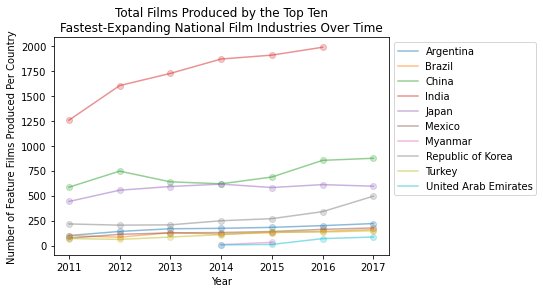

```python
# This line graph is constructed in the mostly same way as were the ones above, but in this
# case there are few enough countries that they can be distinguishably labelled by color using
# a legend
for c in list(topten.columns.values):
    x = natfilms[c]
    plt.plot(natfilms.index.values, x, alpha=0.5)
    plt.scatter(natfilms.index.values, x, alpha=0.25)
plt.xlabel('Year')
plt.ylabel('Number of Feature Films Produced Per Country')
plt.title('Total Films Produced by the Top Ten\nFastest-Expanding National Film Industries Over Time')
plt.legend(topten.columns.values, bbox_to_anchor=(1, 1))
plt.show()
```

Of the top ten countries, there are four for which we have data about their ratio of intranational films to coproductions, or five if you count India. Let's also look at their respective rates of production for those two types of films over time. I am excluding India from these next two graphs for two reasons:

1. We have data for intranational films in India, but no data for the number of Indian coproductions.
2. Less importantly, but still notably, India is so much of an outlier that including it would makes all the other countries' data appear so close together by comparison on such a small graph that it would be difficult to distinguish them.

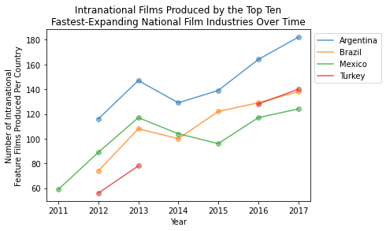

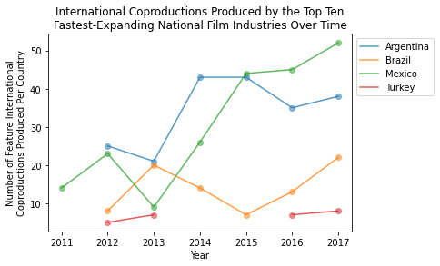

```python
# Plot the intranational film production of the top ten countries in the same way as before,
# except that now we also check to make sure we exclude countries that don't have intranational
# film data or are India
leg = []
for c in list(topten.columns.values):
    if (c in intrafilms.columns.values) & (c != 'India'):
        x = intrafilms[c]
        plt.plot(intrafilms.index.values, x, alpha=0.75)
        plt.scatter(intrafilms.index.values, x, alpha=0.5)
        leg.append(c)
plt.xlabel('Year')
plt.ylabel('Number of Intranational\nFeature Films Produced Per Country')
plt.title('Intranational Films Produced by the Top Ten\nFastest-Expanding National Film Industries Over Time')
plt.legend(leg, bbox_to_anchor=(1, 1))
plt.show()

# Plot the international coproductions of the top ten countries in the same way as above,
# though we don't need to check for India this time because India has no coproduction data
# anyway
leg = []
for c in list(topten.columns.values):
    if c in cofilms.columns.values:
        x = cofilms[c]
        plt.plot(cofilms.index.values, x, alpha=0.75)
        plt.scatter(cofilms.index.values, x, alpha=0.5)
        leg.append(c)
plt.xlabel('Year')
plt.ylabel('Number of Feature International\nCoproductions Produced Per Country')
plt.title('International Coproductions Produced by the Top Ten\nFastest-Expanding National Film Industries Over Time')
plt.legend(leg, bbox_to_anchor=(1, 1))
plt.show()
```

Lastly, we plot the ratio of intranational films to coproductions for each country for which there is data for both categories. This can be done easily by averaging the number of films of each type for each country over the course of each year for which there is data for that country. To make it easy to see how the top ten fastest-growing national film industries compare with the rest, I am printing the labels for the four relevant countries in the top ten in bolded green.

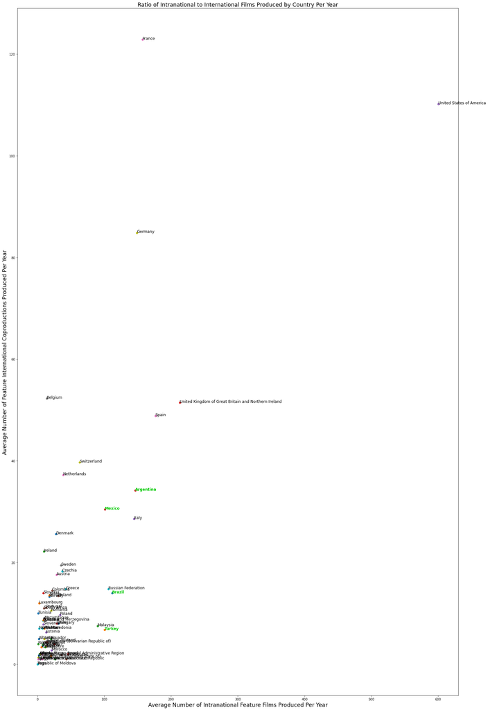

```python
plt.figure(figsize=(25, 40))
# for each country
for c in list(natfilms.columns.values):
    # only do anything if the given country has both intranational and international
    # production data
    if (c in intrafilms.columns.values) & (c in cofilms.columns.values):
        # Calcualte the average numbers of intranational productions and coproductions for the
        # given country, and plot a point using those averages as coordinates. Make sure to
        # only incorporate values into the calculation for years in which there is data for the
        # given country
        x = [0]
        y = [0]
        count = 0
        for ye in cofilms.index.values:
            if not(pd.isnull(intrafilms.at[ye,c]) | pd.isnull(cofilms.at[ye,c])):
                x[0] += intrafilms.at[ye,c]
                y[0] += cofilms.at[ye,c]
                count += 1
        if count != 0:
            x[0] /= count
            y[0] /= count
        plt.scatter(x, y)
        # Print the name of the given country next to the point, with the name appearing in
        # bolded green if the country in question is in our top ten
        w = 'normal'
        col = 'black'
        if c in list(topten.columns.values):
            w = 'bold'
            col = '#00c900'
        plt.text(x[0],y[0],c,size='large',weight=w,color=col)
# Label the axes and display the graph
plt.xlabel('Average Number of Intranational Feature Films Produced Per Year',size='xx-large')
plt.ylabel('Average Number of Feature International Coproductions Produced Per Year',size='xx-large')
plt.title('Ratio of Intranational to International Films Produced by Country Per Year',size='xx-large')
plt.show()
```

### Further Data Analysis

Alright! That's a lot of graphs, so let's start to examine them. In the map we can see what parts of the world are investing in more or fewer films than they used to. More films are being made each year in many parts of Europe, Latin America, and southeast Asia, and the biggest increases in production are happening in eastern and southern Asia, particularly in Japan, Myanmar/Burma, the United Arab Emirates, China, South Korea, and, of course, India, the country which far and away takes the cake for the title of largest cinematic growth rate. Film production is down in central and western Africa, as well as in many Western countries that tend to loom large in the international film trade, including the United Kingdom, New Zealand, and especially the United States, with the USA suffering from the largest average decrease in film production numbers of any country for which we have data. The data doesn't offer any explanations for these global trends, so we will have to make our own inferences, which I will do in the conclusion.

Finally, how do the top ten rising national film industries's ratios of intranational to international films compare to each other and to the rest of the world? The last of our charts illustrates this. This chart is a bit unpleasant to read, with small font and overlapping labels again, but again I didn't want to make the graph so big that it became impossible to read anyway. As we can see, the vast majority of countries produce very small numbers of films at all, and the ones they do produce tend to be coproductions. Of the countries that do produce a substantial number of intranational films, they still make a sizable number of coproductions. France is unique among these countries in that it has the closest ratio of intranational films to coproductions. Among our top ten, Argentina leads in both intranational and international productions. Mexico also puts a sizeable emphasis on coproductions, approaching Argentina in number, which gives it notable standing above Brazil and Turkey, which make similar numbers of intranational films to Mexico each year, but engage in far fewer coproductions.

## Conclusion

I am excited to see countries that are not the traditional leaders in world cinema stepping up their film production. I hope that movies from these places continue to become more available to the rest of the world, so that we all have increased opportunity to leave our usual cultural points of view and broaden our understanding of reality. I do wonder what is motivating these changes in production numbers in these particular countries, and while the data doesn't say, I can hypothesize.

In authoritarian countries like China and the UAE, I think a lot of the increases in production are motivated by government action as part of efforts to modernize, grow the national economies, and decrease reliance of domestic audiences on imported films for entertainment. Movies from these nations are very valuable and worthy of interest; I have seen enough Soviet films to know that artists always try to find a way to communicate their most important ideas, even in the face of government censorship.  
Entertainment from countries like Mexico, Brazil, Japan, and South Korea (countries either in or with strong ties to the West) is becoming increasingly in demand thanks to modern media's popularization of many national genres and auteurs (Bong Joon-Ho, Alejandro González Iñárritu, Kleber Mendonça Filho, Hayao Miyazaki, etc.) for international audiences.  
As for the shrinking number of films per year in the US, I don't think this means the American film industry is diminishing. Rather, American producers are increasingly spending larger amounts of money on fewer and fewer films each year, with funds that used to go towards more diverse projects now being pooled for the budgets of a few "safe bet" films that are usually about a pre-existing franchise that is already familiar with general audiences.  
While American movie producers are making larger bets on a relatively small number of films by well-known filmmakers working with well-known properties (generally aiming for "safe bet" films), it excites me that some countries are becoming more adventurous and growing their film industries through increased production and increased diversity of production. To make this happen, many of these nations are investing in more international coproductions, presumably in order to reach a wider audience and to shoulder less of the financial burden of making a film. Cinematic coproductions can be really cool (if you haven't watched *Crouching Tiger, Hidden Dragon*, do it now), and their benefits are really helpful for artists in many countries that have less of a voice on the international cultural stage, but intranational films are also incredibly important and useful in communicating ideas unique to a certain culture and context. So I hope to see those rise as well.

Finally, this data is, of course, all from the pre-COVID beforetimes. So the pandemic may have shifted the course of the trends that we observe here. Film production in 2020 was obviously way down, which has all sorts of ramifications in the film industry, just on its own, to say nothing of the massive loss of life in many of the countries we have looked at here. But I don't think that ultimately the pandemic will completely derail these trends. Hinder them, yes, but I think that, like the film industries we have looked at here, they will eventually resume their rise.